# Theme 3 Lab Notebook Volume 2

### Description:

Date created: 2 August 2021  
Author: P. Alexander Burnham

**Summary** This document follows my progress on Theme 3 in order to provide a location for me and other members of the team to keep track of this work and maintain annotated description and functioning examples of previous iterations and related vignettes.

### 2 August 2021:

Here I load the GDAL library in python, read in raster files and figure out how to use the package to access the raster data.

```r
#load the reticulate package
library(reticulate)

# activate my previously created conda 3.7 environment
use_condaenv(condaenv = "Python37Env", conda = "auto", required = FALSE)
```

Make sure my 3.7 conda env is loaded

```python
import platform

# make sure python 3.7 is laoded
print(platform.python_version())
```

```
## 3.7.10
```

```python
from osgeo import gdal
import glob
import numpy as np
import matplotlib.pyplot as plt
import time

# set my absolute directory path for where the data are
direc ="/Users/pburnham/Documents/geospatialData/"

# create a list of all raster files that end in .tif
dataPaths = glob.glob(direc+"*.tif")
print(dataPaths)
```

```
## ['/Users/pburnham/Documents/geospatialData/India_cropped-area_1km_2016.tif', '/Users/pburnham/Documents/geospatialData/LULC_1985.tif', '/Users/pburnham/Documents/geospatialData/LULC_1995.tif']
```

```python
timeList = len(dataPaths) # time dimension (three times: 1980-1982 inclusive)

# create raster data set from the second file in the list
ds = gdal.Open(dataPaths[1])
print(type(ds))



# retrieving important meta data info
```

```
## <class 'osgeo.gdal.Dataset'>
```

```python
print(ds.RasterXSize, ds.RasterYSize) # # get dims: 29484 x 33555
```

```
## 29484 33555
```

```python
print(ds.GetProjection()) # get projection info
```

```
## PROJCS["WGS 84 / UTM zone 44N",GEOGCS["WGS 84",DATUM["WGS_1984",SPHEROID["WGS 84",6378137,298.257223563,AUTHORITY["EPSG","7030"]],AUTHORITY["EPSG","6326"]],PRIMEM["Greenwich",0,AUTHORITY["EPSG","8901"]],UNIT["degree",0.0174532925199433,AUTHORITY["EPSG","9122"]],AUTHORITY["EPSG","4326"]],PROJECTIO…
```

```python
print("number of bands:", ds.RasterCount) # there is only one band as expected
```

```
## number of bands: 1
```

```python
print(ds.GetGeoTransform())  # get transform data (corners)
```

```
## (-822562.1628, 100.0, 0.0, 4121824.840487778, 0.0, -100.0)
```

Convert to an array and plot

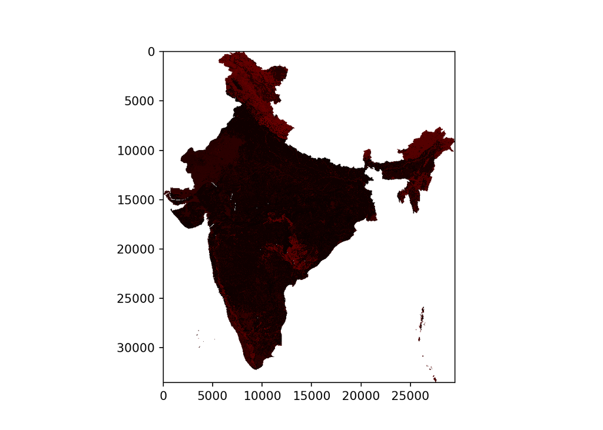

```python
# pull out the band
band = ds.GetRasterBand(1)

# # convert to a large numpy array - may not be the best way to handle things
myarray = np.array(band.ReadAsArray()) #(989,335,620 points on the map)
#
#
# # plt the array as a heat map
plt.imshow(myarray, cmap='hot', interpolation='nearest')
plt.show()
```

Out of curiosity, what is the clock time for dividing a 989 million cell vectorized division process on a numpy array on my m1 macbook.

```python
start = time.process_time()

# divide every cell in the array by 2
x = np.divide(myarray,2)

# print the run time
print("Running time in seconds:", time.process_time() - start)
```

```
## Running time in seconds: 2.268886
```

### 3 August 2021

Here I am attempting to pull in multiple geotiff files and create a list of gdal data sets. I will then scale them to have the same resolution and use the same coordinate systems and measurement schemes. The goal is to use meters, default to EPSG:3857 and default to the highest common scale in terms of granularity. This can be changed in the future. I will use GDAL as it seems that this is the underlying library that is used in most other python geospatial libraries.

```python
from osgeo import gdal
import glob
import numpy as np
import matplotlib.pyplot as plt
import time


# set my absolute directory path for where the data are
direc ="/Users/pburnham/Documents/geospatialData/"

# create a list of all raster files that end in .tif
dataPaths = glob.glob(direc+"*.tif")
#print(dataPaths)

timeList = len(dataPaths) # time dimension (three times: 1980-1982 inclusive)

# initialize a list to store files in during the loop
myDataList = [None] * timeList

# create a list of rasters
for t in range(0, timeList):
   myDataList[t] = gdal.Open(dataPaths[t])




##################################################################################################
# we have rasters of India using different coordinate systems, resulutions and slightly different cropeed frames
# here I will attempt to create a put them on a commmon coordinate system and scale

# print the transformes
print("Course Area:", myDataList[0].GetGeoTransform()) # file one us UTS scaled in degrees
```

```
## Course Area: (68.10625332, 0.008868160000000002, 0.0, 37.0738311, 0.0, -0.00886816)
```

```python
print("Fine Population:", myDataList[1].GetGeoTransform()) # file two is using meters

# get projection info
```

```
## Fine Population: (-822562.1628, 100.0, 0.0, 4121824.840487778, 0.0, -100.0)
```

```python
print("Course Area:", myDataList[0].GetProjection())
```

```
## Course Area: GEOGCS["WGS 84",DATUM["WGS_1984",SPHEROID["WGS 84",6378137,298.257223563,AUTHORITY["EPSG","7030"]],AUTHORITY["EPSG","6326"]],PRIMEM["Greenwich",0],UNIT["degree",0.0174532925199433,AUTHORITY["EPSG","9122"]],AXIS["Latitude",NORTH],AXIS["Longitude",EAST],AUTHORITY["EPSG","4326"]]
```

```python
print("Fine Population:", myDataList[1].GetProjection())


# initialize a list to store altered files
```

```
## Fine Population: PROJCS["WGS 84 / UTM zone 44N",GEOGCS["WGS 84",DATUM["WGS_1984",SPHEROID["WGS 84",6378137,298.257223563,AUTHORITY["EPSG","7030"]],AUTHORITY["EPSG","6326"]],PRIMEM["Greenwich",0,AUTHORITY["EPSG","8901"]],UNIT["degree",0.0174532925199433,AUTHORITY["EPSG","9122"]],AUTHORITY["EPSG","…
```

```python
myDataListScaled = [None] * timeList

# create a list of rasters rescaled to EPSG:3857 with a common grid size
# the resulutions are hard-coded here. Will add flexability nect by picking max dim of all imported rasters
for t in range(0, timeList):
   myDataListScaled[t] = gdal.Warp('', myDataList[t], dstSRS='EPSG:3857', format='VRT',
   outputType=gdal.GDT_Int16,xRes=1052.2047247721555, yRes=-1052.2047247721555)

# reprint the transformes after allteration
print("Course Area:", myDataListScaled[0].GetGeoTransform()) # file one us UTS scaled in degrees
```

```
## Course Area: (7581553.439420097, 1052.2047247721555, 0.0, 4449402.893010777, 0.0, -1052.2047247721555)
```

```python
print("Fine Population:", myDataListScaled[1].GetGeoTransform()) # file two is using meters
```

```
## Fine Population: (7381836.576033083, 1052.2047247721555, 0.0, 4473024.730168145, 0.0, -1052.2047247721555)
```

Here I scale down and make sure non data values are consitant and specified so they are not used in interpolation. Scaling down makes it easier to see what is going on

```python
############################################################################################################
# the overall layer sizes are different but the actual data the rasters are aligned now. Next we have to figure out how
# to write them into a netcdf4 array still aligned with eachother.
# what to do about missing data and overlap is still a question of importance force -9999 as missing data as default
# we can make this a user input


# specifying targetAlignedPixels=True aligns pixels by coordinate system adn scaling down to make sure things are working
# adding missing data arguemnet
for t in range(0, timeList):
   myDataListScaled[t] = gdal.Warp('', myDataList[t], targetAlignedPixels=True, dstSRS='EPSG:3857', format='VRT',
   outputType=gdal.GDT_Int16,xRes=200000, yRes=-200000, dstNodata=-9999, outputBounds="maxY")


print(gdal.Info(myDataListScaled[0]))
```

```
## Driver: VRT/Virtual Raster
## Files: /Users/pburnham/Documents/geospatialData/India_cropped-area_1km_2016.tif
## Size is 13, 19
## Coordinate System is:
## PROJCRS["WGS 84 / Pseudo-Mercator",
##     BASEGEOGCRS["WGS 84",
##         DATUM["World Geodetic System 1984",
##             ELLIPSOID["WGS 84",6378137,298.257223563,
##                 LENGTHUNIT["metre",1]]],
##         PRIMEM["Greenwich",0,
##             ANGLEUNIT["degree",0.0174532925199433]],
##         ID["EPSG",4326]],
##     CONVERSION["Popular Visualisation Pseudo-Mercator",
##         METHOD["Popular Visualisation Pseudo Mercator",
##             ID["EPSG",1024]],
##         PARAMETER["Latitude of natural origin",0,
##             ANGLEUNIT["degree",0.0174532925199433],
##             ID["EPSG",8801]],
##         PARAMETER["Longitude of natural origin",0,
##             ANGLEUNIT["degree",0.0174532925199433],
##             ID["EPSG",8802]],
##         PARAMETER["False easting",0,
##             LENGTHUNIT["metre",1],
##             ID["EPSG",8806]],
##         PARAMETER["False northing",0,
##             LENGTHUNIT["metre",1],
##             ID["EPSG",8807]]],
##     CS[Cartesian,2],
##         AXIS["easting (X)",east,
##             ORDER[1],
##             LENGTHUNIT["metre",1]],
##         AXIS["northing (Y)",north,
##             ORDER[2],
##             LENGTHUNIT["metre",1]],
##     USAGE[
##         SCOPE["Web mapping and visualisation."],
##         AREA["World between 85.06°S and 85.06°N."],
##         BBOX[-85.06,-180,85.06,180]],
##     ID["EPSG",3857]]
## Data axis to CRS axis mapping: 1,2
## Origin = (7400000.000000000000000,4600000.000000000000000)
## Pixel Size = (200000.000000000000000,-200000.000000000000000)
## Metadata:
##   AREA_OR_POINT=Area
##   DataType=Generic
## Corner Coordinates:
## Upper Left  ( 7400000.000, 4600000.000) ( 66d28'31.19"E, 38d 8'43.79"N)
## Lower Left  ( 7400000.000,  800000.000) ( 66d28'31.19"E,  7d10' 3.91"N)
## Upper Right (10000000.000, 4600000.000) ( 89d49'53.50"E, 38d 8'43.79"N)
## Lower Right (10000000.000,  800000.000) ( 89d49'53.50"E,  7d10' 3.91"N)
## Center      ( 8700000.000, 2700000.000) ( 78d 9'12.35"E, 23d33'39.46"N)
## Band 1 Block=13x19 Type=Int16, ColorInterp=Gray
##   NoData Value=-9999
##   Metadata:
##     RepresentationType=ATHEMATIC
```

```python
print(gdal.Info(myDataListScaled[1]))

# pull out the bands
```

```
## Driver: VRT/Virtual Raster
## Files: /Users/pburnham/Documents/geospatialData/LULC_1985.tif
## Size is 20, 20
## Coordinate System is:
## PROJCRS["WGS 84 / Pseudo-Mercator",
##     BASEGEOGCRS["WGS 84",
##         DATUM["World Geodetic System 1984",
##             ELLIPSOID["WGS 84",6378137,298.257223563,
##                 LENGTHUNIT["metre",1]]],
##         PRIMEM["Greenwich",0,
##             ANGLEUNIT["degree",0.0174532925199433]],
##         ID["EPSG",4326]],
##     CONVERSION["Popular Visualisation Pseudo-Mercator",
##         METHOD["Popular Visualisation Pseudo Mercator",
##             ID["EPSG",1024]],
##         PARAMETER["Latitude of natural origin",0,
##             ANGLEUNIT["degree",0.0174532925199433],
##             ID["EPSG",8801]],
##         PARAMETER["Longitude of natural origin",0,
##             ANGLEUNIT["degree",0.0174532925199433],
##             ID["EPSG",8802]],
##         PARAMETER["False easting",0,
##             LENGTHUNIT["metre",1],
##             ID["EPSG",8806]],
##         PARAMETER["False northing",0,
##             LENGTHUNIT["metre",1],
##             ID["EPSG",8807]]],
##     CS[Cartesian,2],
##         AXIS["easting (X)",east,
##             ORDER[1],
##             LENGTHUNIT["metre",1]],
##         AXIS["northing (Y)",north,
##             ORDER[2],
##             LENGTHUNIT["metre",1]],
##     USAGE[
##         SCOPE["Web mapping and visualisation."],
##         AREA["World between 85.06°S and 85.06°N."],
##         BBOX[-85.06,-180,85.06,180]],
##     ID["EPSG",3857]]
## Data axis to CRS axis mapping: 1,2
## Origin = (7200000.000000000000000,4600000.000000000000000)
## Pixel Size = (200000.000000000000000,-200000.000000000000000)
## Metadata:
##   AREA_OR_POINT=Area
##   DataType=Generic
## Corner Coordinates:
## Upper Left  ( 7200000.000, 4600000.000) ( 64d40'43.32"E, 38d 8'43.79"N)
## Lower Left  ( 7200000.000,  600000.000) ( 64d40'43.32"E,  5d22'55.05"N)
## Upper Right (11200000.000, 4600000.000) (100d36'40.72"E, 38d 8'43.79"N)
## Lower Right (11200000.000,  600000.000) (100d36'40.72"E,  5d22'55.05"N)
## Center      ( 9200000.000, 2600000.000) ( 82d38'42.02"E, 22d44' 5.92"N)
## Band 1 Block=20x20 Type=Int16, ColorInterp=Gray
##   NoData Value=-9999
```

```python
band = myDataListScaled[0].GetRasterBand(1)
band1 = myDataListScaled[1].GetRasterBand(1)

# # convert to a numpy array - may not be the best way to handle things
myarray = np.array(band.ReadAsArray())
myarray1 = np.array(band1.ReadAsArray())

# print the arrays
print(myarray)
```

```
## [[-9999 -9999 -9999 -9999 -9999 -9999 -9999 -9999 -9999 -9999 -9999 -9999
##   -9999]
##  [-9999 -9999 -9999     0     0     0 -9999 -9999 -9999 -9999 -9999 -9999
##   -9999]
##  [-9999 -9999 -9999 -9999     1     0     0 -9999 -9999 -9999 -9999 -9999
##   -9999]
##  [-9999 -9999 -9999 -9999     0     0     0 -9999 -9999 -9999 -9999 -9999
##   -9999]
##  [-9999 -9999 -9999 -9999 -9999     0     0 -9999 -9999 -9999 -9999 -9999
##   -9999]
##  [-9999 -9999 -9999 -9999   100    98     0     0 -9999 -9999 -9999 -9999
##   -9999]
##  [-9999 -9999 -9999     0     2    79    53    27 -9999 -9999 -9999 -9999
##   -9999]
##  [-9999 -9999     0     0     8    13     0    28    54   100 -9999 -9999
##       0]
##  [-9999 -9999     0     0    10    95    61     0    24    38    18     0
##       2]
##  [-9999     0     0    64     0     4     0    38     0     0     0     0
##   -9999]
##  [-9999 -9999     0     0     0     0    16     0     4     0     0     0
##   -9999]
##  [-9999 -9999 -9999     0     0     0     0     0     0     0     0 -9999
##   -9999]
##  [-9999 -9999 -9999 -9999     5     0     0     0     0     0 -9999 -9999
##   -9999]
##  [-9999 -9999 -9999 -9999     5     0     0     0    55 -9999 -9999 -9999
##   -9999]
##  [-9999 -9999 -9999 -9999     0     0     0    10 -9999 -9999 -9999 -9999
##   -9999]
##  [-9999 -9999 -9999 -9999 -9999     0     0     0 -9999 -9999 -9999 -9999
##   -9999]
##  [-9999 -9999 -9999 -9999 -9999     0     0 -9999 -9999 -9999 -9999 -9999
##   -9999]
##  [-9999 -9999 -9999 -9999 -9999     0     3 -9999 -9999 -9999 -9999 -9999
##   -9999]
##  [-9999 -9999 -9999 -9999 -9999 -9999 -9999 -9999 -9999 -9999 -9999 -9999
##   -9999]]
```

```python
print(myarray1)

# # plt the array as a heat map
```

```
## [[-9999 -9999 -9999 -9999 -9999 -9999 -9999 -9999 -9999 -9999 -9999 -9999
##   -9999 -9999 -9999 -9999 -9999 -9999 -9999 -9999]
##  [-9999 -9999 -9999 -9999    18    18     6 -9999 -9999 -9999 -9999 -9999
##   -9999 -9999 -9999 -9999 -9999 -9999 -9999 -9999]
##  [-9999 -9999 -9999 -9999 -9999    15     6    18 -9999 -9999 -9999 -9999
##   -9999 -9999 -9999 -9999 -9999 -9999 -9999 -9999]
##  [-9999 -9999 -9999 -9999 -9999    15     4     5 -9999 -9999 -9999 -9999
##   -9999 -9999 -9999 -9999 -9999 -9999 -9999 -9999]
##  [-9999 -9999 -9999 -9999 -9999 -9999     4    10 -9999 -9999 -9999 -9999
##   -9999 -9999 -9999 -9999 -9999 -9999 -9999 -9999]
##  [-9999 -9999 -9999 -9999 -9999     2     2     1     9 -9999 -9999 -9999
##   -9999 -9999 -9999 -9999 -9999 -9999 -9999 -9999]
##  [-9999 -9999 -9999 -9999     6     7     2     2     2 -9999 -9999 -9999
##   -9999 -9999 -9999 -9999    18    15 -9999 -9999]
##  [-9999 -9999 -9999     5     7     7     7     8     2     2     2 -9999
##   -9999     1 -9999    15     2 -9999 -9999 -9999]
##  [-9999 -9999 -9999     7     1     2     2     5     2     9     2     2
##       9     2    15     4    15 -9999 -9999 -9999]
##  [-9999 -9999     1     2     2     7     4     2     2     2     1     1
##       2 -9999 -9999     4 -9999 -9999 -9999 -9999]
##  [-9999 -9999 -9999     2     2     1     1     1    16     2     2     2
##       2    12 -9999 -9999 -9999 -9999 -9999 -9999]
##  [-9999 -9999 -9999 -9999 -9999     2     2     1     5     9     1     2
##   -9999 -9999 -9999 -9999 -9999 -9999 -9999 -9999]
##  [-9999 -9999 -9999 -9999 -9999     2     2     2     4     2     2 -9999
##   -9999 -9999 -9999 -9999 -9999 -9999 -9999 -9999]
##  [-9999 -9999 -9999 -9999 -9999     2     2     2     2     9 -9999 -9999
##   -9999 -9999 -9999 -9999 -9999 -9999 -9999 -9999]
##  [-9999 -9999 -9999 -9999 -9999     1     2     3     2 -9999 -9999 -9999
##   -9999 -9999 -9999 -9999 -9999 -9999 -9999 -9999]
##  [-9999 -9999 -9999 -9999 -9999 -9999    10    10     5 -9999 -9999 -9999
##   -9999 -9999 -9999 -9999 -9999 -9999 -9999 -9999]
##  [-9999 -9999 -9999 -9999 -9999 -9999     2     2 -9999 -9999 -9999 -9999
##   -9999 -9999 -9999 -9999 -9999 -9999 -9999 -9999]
##  [-9999 -9999 -9999 -9999 -9999 -9999    10    10 -9999 -9999 -9999 -9999
##   -9999 -9999 -9999 -9999 -9999 -9999 -9999 -9999]
##  [-9999 -9999 -9999 -9999 -9999 -9999 -9999 -9999 -9999 -9999 -9999 -9999
##   -9999 -9999 -9999 -9999 -9999 -9999 -9999 -9999]
##  [-9999 -9999 -9999 -9999 -9999 -9999 -9999 -9999 -9999 -9999 -9999 -9999
##   -9999 -9999 -9999 -9999 -9999 -9999 -9999 -9999]]
```

[figure not shown]

```python
plt.imshow(myarray, cmap='hot', interpolation='nearest')
plt.show()

# # plt the array as a heat map
```

[figure not shown]

```python
plt.imshow(myarray1, cmap='hot', interpolation='nearest')
plt.show()
```

### 5 August 2021

Here I create a function that pulls in raster file names and returns a list of geospatially aligned raster objects of the same type

```python
from osgeo import gdal
import glob
import numpy as np

#############################################################################################################
# DESCRIPTION: This function called raster_align takes a list of raster names, loads the rasters
# into memory and ensures they have the same aligned structure with the correct SRS codes and consitant resolutions
#
# AUTHOR: P. Alexander Burnham
# 5 August 2021
#
# INPUTS:
# rastNames (required): a list or array of file names including the required path if in another directory.
# resolution: the pixel dimensions to be used for all rasters. Defaults to the largest common pixel size
# SRS: this is the SRS code that sets the units and geospatial scale. Defaults to EPSG:3857 like google maps
# noneVal: the value to be used for pixels in the raster that contain no value. Defaults to -9999
#
# OUTPUT:
# It outputs a list of rescaled and gepspatialy aligned rasters
#############################################################################################################
def raster_align(rastNames=None, resolution=None, SRS=3857, noneVal=-9999):

    if rastNames is None:
        print("Error: No file list provided! Please pass raster_align a list of raster file names.")
        quit() # exit program and display message when no file names provided

    # define the espg code as a character for GDAL
    SRS_code = "EPSG:" + str(SRS)

    timeList = len(rastNames) # time dimension for list

    # initialize a mat to store files in during the loop and one to store the modification
    dataMat = [[0] * 3 for i in range(timeList)]

    # create a list of rasters in first column
    for t in range(0, timeList):
        dataMat[0][t] = gdal.Open(rastNames[t])

    # if resolution is not provided, default to the greatest common resolution
    if resolution is None:
        # get greatest common dimension
        for j in range(0, timeList):

            # put on same scale based on the SRS code to get consistant resolution values
            temp = gdal.Warp('', dataMat[0][j], dstSRS=SRS_code, format='VRT')
            dataMat[1][j] = temp.GetGeoTransform()[1]

        temp=None # flush from disk

        # get max resolution value
        resolution = np.max(dataMat[1][:])

    # do transformation and alingnment
    for i in range(0, timeList):
        dataMat[2][i] = gdal.Warp('', dataMat[0][i], targetAlignedPixels=True, dstSRS=SRS_code, format='VRT',
        outputType=gdal.GDT_Int16, xRes=resolution, yRes=-resolution, dstNodata=noneVal)

    return dataMat[2][:]
#############################################################################################################
# END FUNCTION
#############################################################################################################
```

Here is a driver that calls this function as an example.

```python
import glob
import numpy as np
import matplotlib.pyplot as plt
import netCDF4 as nc
from rasterAlign import *


# set my absolute directory path for where the data are
direc ="/Users/pburnham/Documents/geospatialData/"

# create a list of all raster files that end in .tif
dataPaths = glob.glob(direc+"*.tif")


# call the raster align function
alignedRasters = raster_align(rastNames=dataPaths)

# print the origins and pixel sizes for all three files after the transform
print(alignedRasters[0].GetGeoTransform(1))
```

```
## (7581135.04198338, 1052.2047247721555, 0.0, 4449773.781061445, 0.0, -1052.2047247721555)
```

```python
print(alignedRasters[1].GetGeoTransform(1))
```

```
## (7381216.144276671, 1052.2047247721555, 0.0, 4473974.489731205, 0.0, -1052.2047247721555)
```

```python
print(alignedRasters[2].GetGeoTransform(1))


# Specify srs 4326 vs 3857
```

```
## (7381216.144276671, 1052.2047247721555, 0.0, 4473974.489731205, 0.0, -1052.2047247721555)
```

```python
alignedRastersCustom = raster_align(rastNames=dataPaths, noneVal=-9999, SRS=4326)

print(alignedRastersCustom[0].GetGeoTransform(1))
```

```
## (68.09860064, 0.00886816, 0.0, 37.07777696, 0.0, -0.00886816)
```

```python
print(alignedRastersCustom[1].GetGeoTransform(1))
```

```
## (66.30723232, 0.00886816, 0.0, 37.246272, 0.0, -0.00886816)
```

```python
print(alignedRastersCustom[2].GetGeoTransform(1))


# 3857 with a large pixel size
```

```
## (66.30723232, 0.00886816, 0.0, 37.246272, 0.0, -0.00886816)
```

```python
alignedRastersDims = raster_align(rastNames=dataPaths, noneVal=-0, resolution=10000)

print(alignedRastersDims[0].GetGeoTransform(1))
```

```
## (7580000.0, 10000.0, 0.0, 4450000.0, 0.0, -10000.0)
```

```python
print(alignedRastersDims[1].GetGeoTransform(1))
```

```
## (7380000.0, 10000.0, 0.0, 4480000.0, 0.0, -10000.0)
```

```python
print(alignedRastersDims[2].GetGeoTransform(1))
```

```
## (7380000.0, 10000.0, 0.0, 4480000.0, 0.0, -10000.0)
```

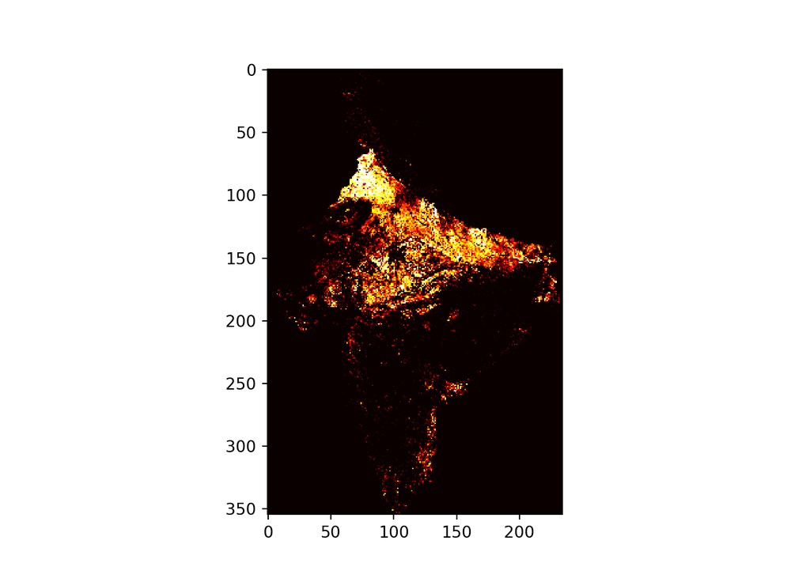

```python
ds = alignedRastersDims[0].ReadAsArray()
im = plt.imshow(ds, cmap='hot', interpolation='nearest')
plt.show()
```

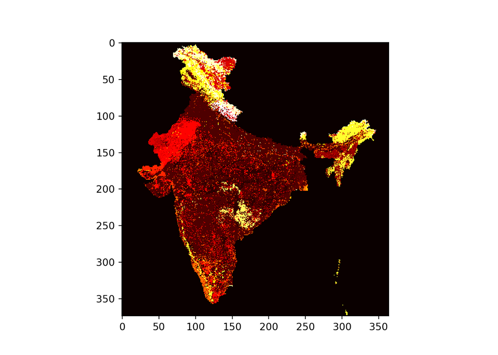

```python
ds1 = alignedRastersDims[1].ReadAsArray()
im1 = plt.imshow(ds1, cmap='hot', interpolation='nearest')
plt.show()
```